# bak_lab11

Jakub Bąk

17 01 2021

# Zadania 11 laboratorium

Wstepne przetworzenie danych

```r
library("PogromcyDanych")
library("archivist")
auta <- auta2012
auta$nazwa <- rownames(auta)
auta$Cena_norm <- scale(sqrt(auta$Cena))
mean_km <- mean(auta$KM, na.rm=TRUE)
auta$KM[is.na(auta$KM)] <- mean_km
auta$KM_norm <- scale(sqrt(auta$KM))
head(auta)
```

```
##    Cena Waluta Cena.w.PLN Brutto.netto      KM  kW         Marka     Model
## 1 49900    PLN      49900       brutto 140.000 103           Kia    Carens
## 2 88000    PLN      88000       brutto 156.000 115    Mitsubishi Outlander
## 3 86000    PLN      86000       brutto 150.000 110     Chevrolet   Captiva
## 4 25900    PLN      25900       brutto 163.000 120         Volvo       S80
## 5 55900    PLN      55900        netto 127.426  NA Mercedes-Benz  Sprinter
## 6 45900    PLN      45900        netto 150.000 110 Mercedes-Benz     Viano
##   Wersja Liczba.drzwi Pojemnosc.skokowa Przebieg.w.km          Rodzaj.paliwa
## 1                 4/5              1991         41000 olej napedowy (diesel)
## 2                 4/5              2179         46500 olej napedowy (diesel)
## 3                 4/5              1996          8000 olej napedowy (diesel)
## 4                 4/5              2400        200000 olej napedowy (diesel)
## 5                 4/5              2200        169400 olej napedowy (diesel)
## 6                 4/5              2200        141100 olej napedowy (diesel)
##   Rok.produkcji            Kolor Kraj.aktualnej.rejestracji Kraj.pochodzenia
```

[output cut: 27 more lines]

```r
library(dplyr)
set.seed(3243)
sample_auta <- sample_n(auta,57)
```

Notes: Na poczatku z biblioteki Pogromcy Danych wczytuje zbior danych “auta2012”. Nastepnie przypisuje autom nazw, oraz standaryzuje zmienne “Cena” oraz “KM”, dla ulatwienia analizy, a takze lepszej jej reprezentacji na wykresie. Dodatkowo poniewaz zmienna “KM” miala sporo brakow, brakujace wartosci zastapilem wartoscia srednia, a dopiero wtedy ja ustandaryzowalem. Nastepnie skorzystalem z biblioteki “dplyr”, aby wybrac tylko czesc danych z ponad 200 tys rekordow w zbiorze danych, w celu skrocenia czasu wyszukiwania grup oraz na potrzeby samego zadania. Dodatkowo ustawilem seeda aby moc replikowac te same dane do kazdej analizy

Grupowanie k-srednich: Wyswietlenie danych na wykresie

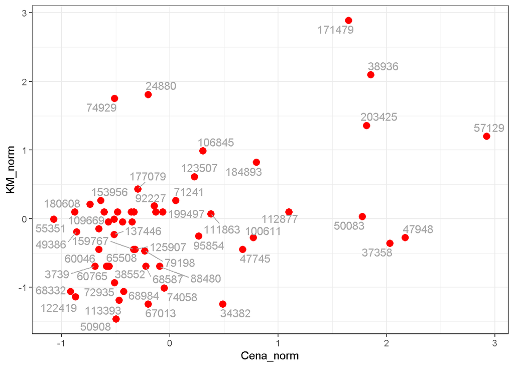

```r
library(ggrepel)
ggplot(sample_auta, aes(Cena_norm, KM_norm, label=nazwa)) +
  geom_point(size=3, color="red") +
  geom_text_repel(color="darkgrey") + theme_bw()
```

Grupowanie k-srednich: Podzial na 4 grupy

```r
grupy <- kmeans(sample_auta[,c("Cena_norm", "KM_norm")],
                centers = 4, nstart = 10)

head(grupy$cluster)
```

```
## [1] 3 3 3 4 2 3
```

```r
grupy$centers
```

```
##    Cena_norm     KM_norm
## 1  1.3299210 -0.05582948
## 2 -0.3500187  0.25131798
## 3 -0.4076235 -0.85731496
## 4  2.0590410  1.88768724
```

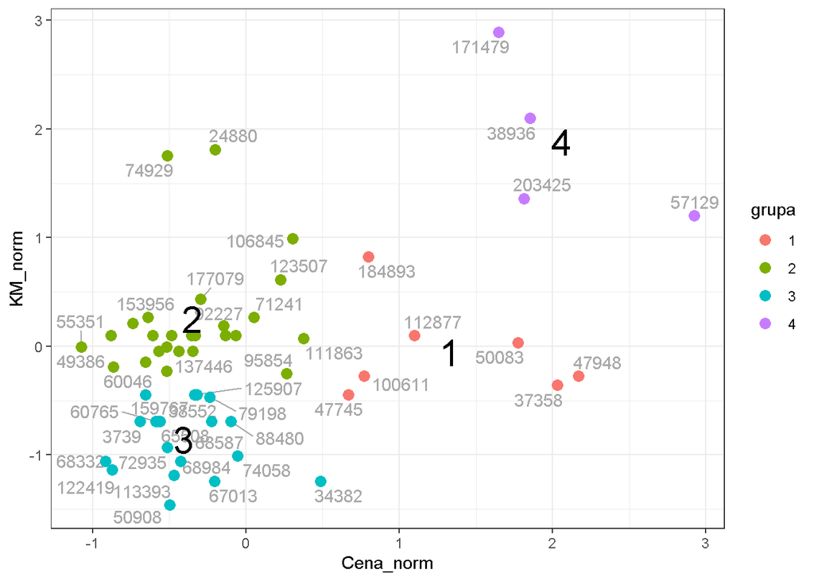

```r
sample_auta$grupa <- factor(grupy$cluster)
centra <- data.frame(grupy$centers)
centra$nazwa <- centra$grupy <- factor(1:nrow(centra))

ggplot(sample_auta, aes(Cena_norm, KM_norm, color=grupa, label=nazwa)) +
  geom_text_repel(color="darkgrey") +
  geom_point(size=3) +
  geom_text(data=centra, size=8, color="black") +  theme_bw()
```

Grupowanie k-srednich: Podzial na 3 grupy

```r
grupy_2 <- kmeans(sample_auta[,c("Cena_norm", "KM_norm")],
                centers = 3, nstart = 10)

head(grupy_2$cluster)
```

```
## [1] 1 1 1 3 2 1
```

```r
grupy_2$centers
```

```
##    Cena_norm    KM_norm
## 1 -0.3538104 -0.8367051
## 2 -0.3100466  0.2325987
## 3  1.7897522  0.8753203
```